# Survey Experiment

Does Information About Repression Shift Support for Authoritarian Regimes?

Daniel Kuhlen

Giovanna Lapresa

Jorge Zavala

2026-02-24

# 1. Question & Motivation

## Research Question

> **Does Information About Repression Shift Support for Authoritarian Regimes?**
- Information about repression can trigger **backlash** — but only under specific conditions (target sympathy, media framing, group identity) (Davenport 2007)
- A lot of people support repression!
  - We lack **causal evidence** on when and why citizens support state-violence

## Theory: A triadic model of repression

- Repression is not dyadic (state ↔︎ dissidents) — it is **triadic** (Lachapelle 2022; Zhu et al. 2025):

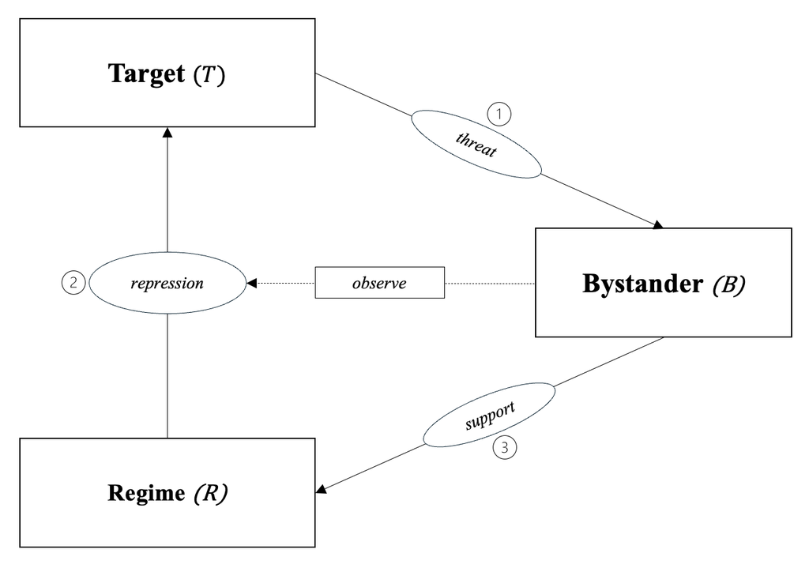

| Mechanism | Prediction |
| --- | --- |
| Threat-conditional legitimation | High threat → more repression support |
| Backlash | Sympathetic targets + HRV info → less support |
| Out-group permissiveness | Out-group targets → support persists even without threat |

## Connection to Broader Research Agenda

- **Daniel:** 1 PhD paper on this mechanism for the case of militarized policing - would like to add this to PhD
- **Jorge:** Political violence
- **Giovanna:** Political violence

# 2. Key Design Elements

## Population of Interest

[output not shown]

## Inquiry: Causal Effect Estimation

**Inquiry**

*Does Information About Repression Shift Support for Authoritarian Regimes?*

**Data strategy**

Random assignment of information exposure in a survey vignette

- **Estimand:** ATE of HRV information on support for targeted repression

## Assignment Scheme

**2 × 2 between-subjects factorial design**

|  | No Threat | Threat |
| --- | --- | --- |
| **No HRV information** | Control (n = 500) | Threat only (n = 500) |
| **HRV information exposed** | HRV only (n = 500) | Threat + HRV (n = 500) |

## Vignettes

We are thinking about three potential cases to do this:

1. hypothetical scenario: *imagine a state x …*
2. real-world case of repression / state violence (ethics?)
3. repression / state violence by Germany (frontex? police brutality?)

## Analysis Plan

- **estimator:** OLS / difference-in-means (ATE per arm)
- **outcome:** support for authoritarian regime, aid-allocation, support for cooperation

# 3. Implementation

## Team

[output not shown]

## Survey Instrument

- **Flow:** Consent → Screener/covariates → Treatment vignette → Outcome battery → Manipulation check → Debriefing
- **Key blocks:**
  - *Pre-treatment:* age, gender, education, political interest, prior trust in police
  - *Treatment vignette:* ~100–150 word scenario
  - *Post-treatment:* outcome battery
  - *Manipulation check:* recall of scenario characteristics and information exposure

## Timing

| Module | Estimated time |
| --- | --- |
| Background questions (covariates) | ~1 min |
| Treatment vignette | ~1 min |
| Outcome battery | ~2 min |
| Manipulation check | ~1 min |
| **Total** | **~5 min** |

## Risks

- **Attrition:** Differential dropout if HRV information is distressing — will monitor dropout rates by condition; include opt-out option
- **Manipulation failure:** HRV information may not be read carefully — addressed by comprehension check and attention screener

## Ethical Considerations

# 4. Open Questions

## Literature

Field Experiments Class 2026

Davenport, Christian. 2007. “State Repression and Political Order.” *Annual Review of Political Science* 10 (1): 1–23. https://doi.org/10.1146/annurev.polisci.10.101405.143216.

Lachapelle, Jean. 2022. “Repression Reconsidered: Bystander Effects and Legitimation in Authoritarian Regimes.” *Comparative Politics* 54 (4): 695–716. https://doi.org/10.5129/001041522X16317396828722.

Zhu, Jiangnan, Steve Bai, Siqin Kang, Juan Wang, and Kaixiao Liu. 2025. “Authoritarian Cue Effect of State Repression.” *American Journal of Political Science* 69 (4): 1420–34. https://doi.org/10.1111/ajps.12916.